# Team 1 Stepping Stones Variables: Final

## Housing

### Adults experiencing Homelessness

#### Trend

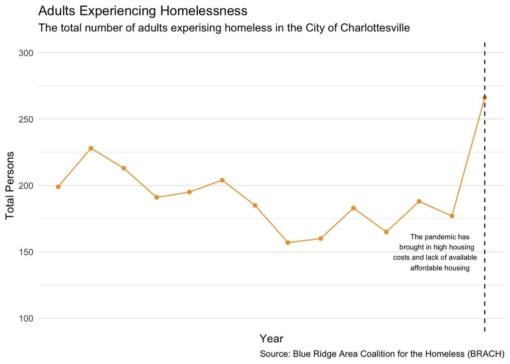

#### About

The Blue Ridge Area Coalition for the Homelesss (BRACH) aims to make homelessness rare, brief and nonrecurring in our community. Some of the key services offered by BRACH include emergency shelter, transitional housing, case management, and job training and placement assistance. The organization also provides food, clothing, and other basic necessities to those in need. BRACH relies on the support of volunteers and donations from individuals, businesses, and organizations to fund its programs and services. Its work has made a significant impact in the community, helping to provide crucial support to those who are struggling with homelessness and working towards a future where everyone has access to safe and stable housing.

- **Why is this important?** Knowing the population of homelessness is crucial to identify the needs of the homeless population and allocate resources effectively. Accurate data on the homeless population can also help set specific goals, collaborate with other organizations, and advocate for policy changes. By using data to inform its work, the project can make a positive impact in the lives of homeless individuals and families in the community. Additionally, by monitoring the population of homelessness, it is possible to evaluate the effectiveness of interventions and programs, and make necessary adjustments to ensure that resources are being used effectively.
- **Further Considerations:** Homelessness can be affected by seasonal factors, like weather conditions and changes in the economy. Therefore along with looking at trends over multiple years to identify patterns, further data can be considered which looks at seasonal fluctuations, which may more accurately identify the causes and policy effects of this data. Changes in the demographics of the homeless population, such as changes in the age or gender of those experiencing homelessness, can also provide insight into the underlying causes of homelessness and inform targeted interventions. Trends in the homeless population can also be affected by changes in the availability and affordability of housing in Charlottesville. Examining trends in housing prices, evictions, and rental vacancies can provide context for changes in the homeless population. Changes in the size and demographics of the homeless population can also be influenced by changes in outreach and intervention efforts, such as increased funding for homeless services or changes in how services are delivered. It’s important to examine how changes in these efforts may be impacting the homeless population over time. Finally, looking at this data in comparison with nearby cities, counties, and the state as a whole may also be useful in better understanding trends and opportunities for policy changes.
- **Trend:** The trend over the years shows general stability until 2022 where there is a rise in the number. This could be attributed to the COVID 19 pandemic that occured over the previous two years, which brought [high housing costs and a lack of available housing](https://infocville.com/2022/05/03/council-briefed-on-increase-in-homelessness-in-charlottesville-area/#:~:text=%E2%80%9CThe%20most%20significant%20shift%20has,affordable%20housing%2C%E2%80%9D%20Haro%20said.)
- **How do we measure this?** The total number of persons experiencing homeless in Charlottesville. This was the only data obtained from BRACH.
- **Data source:** Blue Ridge Area Coalition for the Homeless(BRACH)